# GaPs Results B: the maternal–infant antibody pathway (Figure 3 + supplemental table)

Within-subject production, placental transfer, and postnatal decay — pooled and by maternal arm

Scot Zens and Anja Saso

2026-06-30

# A. Study population

Table 1. Study-population characteristics, overall and by maternal arm (Tdap-IPV vs TT). Continuous variables: median [IQR]; categorical: n (%).

| Characteristic | Overall | TdaP | TT |
| --- | --- | --- | --- |
| n | 239 | 117 | 122 |
| maternal_age, median [IQR] | 26.4 [23.7, 30.0] | 26.5 [23.5, 30.8] | 26.3 [23.8, 28.8] |
| maternal_bmi, median [IQR] | 24.1 [21.4, 26.4] | 23.6 [21.0, 26.2] | 24.3 [22.1, 26.5] |
| maternal_Hb, median [IQR] | 10.6 [10.0, 11.3] | 10.6 [10.0, 11.3] | 10.6 [10.0, 11.6] |
| gestational_age_vaccination, median [IQR] | 29.0 [28.0, 31.0] | 29.0 [28.0, 31.0] | 29.0 [28.0, 31.0] |
| gestational_age_birth, median [IQR] | 39.0 [38.0, 40.0] | 39.0 [38.0, 40.0] | 39.0 [38.0, 40.0] |
| vaccine_birth_interval_days, median [IQR] | 67.0 [56.0, 77.0] | 68.0 [56.0, 76.0] | 66.5 [56.0, 78.0] |
| birth_weight, median [IQR] | 3.0 [2.7, 3.2] | 2.9 [2.7, 3.2] | 3.0 [2.7, 3.2] |
| parity, n (%) |  |  |  |
| 0 | 66 (28%) | 34 (29%) | 32 (26%) |
| 1 | 63 (26%) | 34 (29%) | 29 (24%) |
| 2+ | 109 (46%) | 49 (42%) | 60 (49%) |
| NA | 1 (0%) | 0 (0%) | 1 (1%) |
| infant_sex, n (%) |  |  |  |
| Female | 128 (54%) | 60 (51%) | 68 (56%) |
| Male | 111 (46%) | 57 (49%) | 54 (44%) |
| delivery_mode, n (%) |  |  |  |
| Caesarian Section | 13 (5%) | 5 (4%) | 8 (7%) |
| Vaginal Delivery | 226 (95%) | 112 (96%) | 114 (93%) |

# B. The maternal–infant antibody pathway

We trace three within-subject transitions with the shared `paired_change()` / `summarise_paired()` machinery (delta = log10 at the later visit − log10 at the earlier visit; Wilcoxon signed-rank vs 0):

- **Production** PregEarly → MatBirth — antibody made during pregnancy
- **Transfer** MatBirth → CordBlood — placental transfer to the infant
- **Decay** CordBlood → InfMon2 — postnatal decay of the maternal pool

## Figure 3 — maternal–infant antibody pathway (expanded: total IgG + IgG1–IgG4)

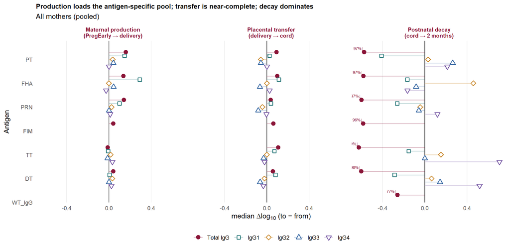

### Figure 3 — Tdap-IPV mothers

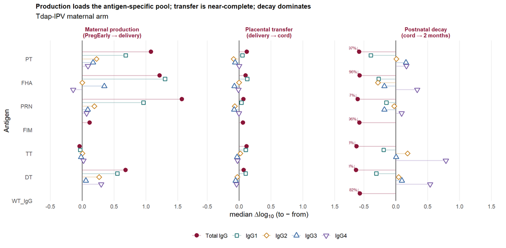

### Figure 3 — TT mothers

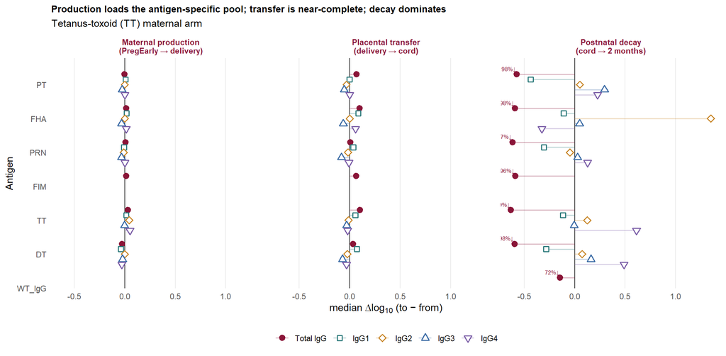

*Per-arm panels resolve the toxoid question directly: both maternal vaccines contain tetanus toxoid, so TT-antigen IgG production should rise in both arms (subject to a pre-existing-immunity ceiling), whereas diphtheria toxoid is in the Tdap-IPV arm only, so DT-antigen IgG production should rise mainly after Tdap-IPV. Read the TT and DT rows of the production (left) panel in each arm figure.*

## Table 1 — transition summary (per antigen, total IgG and IgG1)

Table 1. Within-subject paired change for each antigen across the three pathway transitions.

| Transition | Antigen | Analyte | n | % increase | % decrease | median Δlog10 | p (signed-rank) | Direction |
| --- | --- | --- | --- | --- | --- | --- | --- | --- |
| Maternal production | PT | IgG1 | 243 | 72.8 | 25.9 | 0.148 | 0.00e+00 | mostly increase |
| Maternal production | PT | Total IgG | 283 | 70.3 | 29.7 | 0.161 | 0.00e+00 | mostly increase |
| Maternal production | FHA | IgG1 | 243 | 74.5 | 25.5 | 0.292 | 0.00e+00 | mostly increase |
| Maternal production | FHA | Total IgG | 283 | 74.6 | 25.4 | 0.138 | 0.00e+00 | mostly increase |
| Maternal production | PRN | IgG1 | 243 | 67.9 | 30.9 | 0.100 | 0.00e+00 | mostly increase |
| Maternal production | PRN | Total IgG | 283 | 72.4 | 27.6 | 0.142 | 0.00e+00 | mostly increase |
| Maternal production | FIM | Total IgG | 283 | 60.8 | 38.5 | 0.042 | 3.63e-05 | mostly increase |
| Maternal production | TT | IgG1 | 243 | 48.6 | 51.4 | -0.008 | 7.23e-01 | mixed |
| Maternal production | TT | Total IgG | 283 | 48.1 | 51.9 | -0.011 | 8.47e-01 | mixed |
| Maternal production | DT | IgG1 | 243 | 51.0 | 46.5 | 0.007 | 1.08e-04 | mixed |
| Maternal production | DT | Total IgG | 283 | 58.0 | 42.0 | 0.041 | 8.00e-07 | mixed |
| Placental transfer | PT | IgG1 | 240 | 55.8 | 43.3 | 0.025 | 2.22e-01 | mixed |
| Placental transfer | PT | Total IgG | 283 | 75.6 | 24.4 | 0.092 | 0.00e+00 | mostly increase |
| Placental transfer | FHA | IgG1 | 240 | 70.8 | 28.8 | 0.113 | 0.00e+00 | mostly increase |
| Placental transfer | FHA | Total IgG | 283 | 73.9 | 26.1 | 0.099 | 0.00e+00 | mostly increase |
| Placental transfer | PRN | IgG1 | 240 | 68.8 | 30.0 | 0.037 | 0.00e+00 | mostly increase |
| Placental transfer | PRN | Total IgG | 283 | 61.1 | 38.9 | 0.037 | 3.17e-04 | mostly increase |
| Placental transfer | FIM | Total IgG | 283 | 63.6 | 35.7 | 0.062 | 2.30e-06 | mostly increase |
| Placental transfer | TT | IgG1 | 240 | 76.2 | 23.8 | 0.071 | 0.00e+00 | mostly increase |
| Placental transfer | TT | Total IgG | 283 | 79.2 | 20.8 | 0.107 | 0.00e+00 | mostly increase |
| Placental transfer | DT | IgG1 | 240 | 73.3 | 26.2 | 0.081 | 0.00e+00 | mostly increase |
| Placental transfer | DT | Total IgG | 283 | 64.0 | 36.0 | 0.057 | 1.00e-07 | mostly increase |
| Postnatal decay | PT | IgG1 | 197 | 5.1 | 94.9 | -0.411 | 0.00e+00 | mostly decrease |
| Postnatal decay | PT | Total IgG | 262 | 2.7 | 97.3 | -0.575 | 0.00e+00 | mostly decrease |
| Postnatal decay | FHA | IgG1 | 197 | 23.9 | 76.1 | -0.167 | 0.00e+00 | mostly decrease |
| Postnatal decay | FHA | Total IgG | 262 | 3.1 | 96.9 | -0.581 | 0.00e+00 | mostly decrease |
| Postnatal decay | PRN | IgG1 | 197 | 15.2 | 84.8 | -0.262 | 0.00e+00 | mostly decrease |
| Postnatal decay | PRN | Total IgG | 262 | 3.1 | 96.9 | -0.600 | 0.00e+00 | mostly decrease |
| Postnatal decay | FIM | Total IgG | 262 | 3.1 | 95.8 | -0.584 | 0.00e+00 | mostly decrease |
| Postnatal decay | TT | IgG1 | 197 | 22.3 | 77.7 | -0.154 | 0.00e+00 | mostly decrease |
| Postnatal decay | TT | Total IgG | 262 | 1.1 | 98.9 | -0.624 | 0.00e+00 | mostly decrease |
| Postnatal decay | DT | IgG1 | 197 | 7.6 | 92.4 | -0.288 | 0.00e+00 | mostly decrease |
| Postnatal decay | DT | Total IgG | 262 | 2.3 | 97.7 | -0.601 | 0.00e+00 | mostly decrease |

## Consolidated pathway findings (computed by arm)

**Production (PregEarly → delivery).** Median Δlog10 across the six antigens for IgG1: pooled +0.100, TdaP +0.681, TT +0.007; for total IgG: pooled +0.090, TdaP +0.879, TT +0.010. The rise concentrates in the TdaP arm and in total IgG / IgG1, the expected signature of a protein-antigen booster. Toxoid check (total-IgG production): tetanus TdaP -0.042 / TT +0.030; diphtheria TdaP +0.680 / TT -0.028 — tetanus is in both vaccines (it can rise in both, subject to a pre-existing-immunity ceiling), whereas diphtheria rises mainly after Tdap-IPV.

**Transfer (delivery → cord).** IgG1 median Δ pooled +0.071 (cord ≥ maternal) versus IgG2 -0.023 and IgG3 -0.065 (cord ≤ maternal) — the FcRn subclass hierarchy. Per-arm IgG1 transfer: TdaP +0.103, TT +0.055, close together, consistent with an Fc-driven mechanism that does not depend on the vaccine received.

**Decay (cord → 2 months).** Total IgG median Δ pooled -0.592 and IgG1 -0.262 — net decay of passively transferred antibody. Per-arm IgG1 decay: TdaP -0.270, TT -0.282, running in parallel, as catabolism is set by the antibody rather than the vaccine: the vaccine sets the cord starting level, not the slope of waning. Total IgG (RIVM ELISA) and IgG1 (bead array) agree, anchoring the decay signal as real.

## Supplemental Table S1 — full pathway change (all series × antigen × transition × arm)

Supplemental Table S1. Full within-subject paired change behind Figure 3: each vaccine antigen (PT, FHA, PRN, FIM, TT, DT) × series (total IgG and IgG1–IgG4) × transition (production, transfer, decay) × maternal arm (Pooled, TdaP, TT). delta = log10(later) − log10(earlier); positive = increase. Rows are absent where a series was not measured at both visits (e.g. FIM subclasses before InfMon2) or fell below the n = 10 paired minimum within an arm.

| Transition | Antigen | Series | Arm | n | % inc | % dec | median Δlog10 | p (signed-rank) | Direction |
| --- | --- | --- | --- | --- | --- | --- | --- | --- | --- |
| Maternal production | PT | Total IgG | Pooled | 283 | 70.3 | 29.7 | 0.161 | 0.00e+00 | mostly increase |
| Maternal production | PT | Total IgG | TdaP | 130 | 95.4 | 4.6 | 1.078 | 0.00e+00 | mostly increase |
| Maternal production | PT | Total IgG | TT | 153 | 49.0 | 51.0 | -0.004 | 5.67e-01 | mixed |
| Maternal production | PT | IgG1 | Pooled | 243 | 72.8 | 25.9 | 0.148 | 0.00e+00 | mostly increase |
| Maternal production | PT | IgG1 | TdaP | 112 | 96.4 | 3.6 | 0.681 | 0.00e+00 | mostly increase |
| Maternal production | PT | IgG1 | TT | 131 | 52.7 | 45.0 | 0.007 | 8.13e-01 | mixed |
| Maternal production | PT | IgG2 | Pooled | 231 | 59.7 | 27.7 | 0.036 | 0.00e+00 | mixed |
| Maternal production | PT | IgG2 | TdaP | 105 | 92.4 | 6.7 | 0.223 | 0.00e+00 | mostly increase |
| Maternal production | PT | IgG2 | TT | 126 | 32.5 | 45.2 | 0.000 | 2.64e-01 | mostly decrease |
| Maternal production | PT | IgG3 | Pooled | 237 | 55.7 | 35.0 | 0.042 | 7.00e-07 | mixed |
| Maternal production | PT | IgG3 | TdaP | 109 | 87.2 | 9.2 | 0.168 | 0.00e+00 | mostly increase |
| Maternal production | PT | IgG3 | TT | 128 | 28.9 | 57.0 | -0.027 | 1.51e-04 | mostly decrease |
| Maternal production | PT | IgG4 | Pooled | 243 | 48.6 | 30.0 | 0.000 | 0.00e+00 | mixed |
| Maternal production | PT | IgG4 | TdaP | 112 | 77.7 | 9.8 | 0.087 | 0.00e+00 | mostly increase |
| Maternal production | PT | IgG4 | TT | 131 | 23.7 | 47.3 | 0.000 | 5.47e-03 | mostly decrease |
| Maternal production | FHA | Total IgG | Pooled | 283 | 74.6 | 25.4 | 0.138 | 0.00e+00 | mostly increase |
| Maternal production | FHA | Total IgG | TdaP | 130 | 95.4 | 4.6 | 1.213 | 0.00e+00 | mostly increase |
| Maternal production | FHA | Total IgG | TT | 153 | 56.9 | 43.1 | 0.015 | 2.71e-01 | mixed |
| Maternal production | FHA | IgG1 | Pooled | 243 | 74.5 | 25.5 | 0.292 | 0.00e+00 | mostly increase |
| Maternal production | FHA | IgG1 | TdaP | 112 | 97.3 | 2.7 | 1.298 | 0.00e+00 | mostly increase |
| Maternal production | FHA | IgG1 | TT | 131 | 55.0 | 45.0 | 0.018 | 2.69e-01 | mixed |
| Maternal production | FHA | IgG2 | Pooled | 231 | 45.0 | 33.3 | 0.000 | 1.14e-02 | mixed |
| Maternal production | FHA | IgG2 | TdaP | 105 | 40.0 | 48.6 | 0.000 | 6.82e-01 | mostly decrease |
| Maternal production | FHA | IgG2 | TT | 126 | 49.2 | 20.6 | 0.000 | 2.82e-05 | mixed |
| Maternal production | FHA | IgG3 | Pooled | 237 | 58.6 | 38.8 | 0.044 | 0.00e+00 | mixed |
| Maternal production | FHA | IgG3 | TdaP | 109 | 89.0 | 11.0 | 0.343 | 0.00e+00 | mostly increase |
| Maternal production | FHA | IgG3 | TT | 128 | 32.8 | 62.5 | -0.032 | 5.84e-04 | mostly decrease |
| Maternal production | FHA | IgG4 | Pooled | 243 | 39.5 | 55.6 | -0.026 | 9.98e-04 | mostly decrease |
| Maternal production | FHA | IgG4 | TdaP | 112 | 23.2 | 75.9 | -0.145 | 0.00e+00 | mostly decrease |
| Maternal production | FHA | IgG4 | TT | 131 | 53.4 | 38.2 | 0.013 | 1.98e-02 | mixed |

[output cut: 204 more lines]

# Notes (Part B)

- Section B (the pathway figure, Table 1, the consolidated by-arm findings, and Supplemental Table S1) is computed here from `c_set.RData`; every quoted number is generated at knit time, with no values carried over from earlier runs.
- The antibody **correlates of infant function** (former sections C–F) now live in a separate document, `results_C_to_F.Rmd`, which also lays out the methodological strategy for the variance structure of the infant whole-cell (WHOLE_WT_IgG) outcome at two months.
- Pre-existing caption note: the study-population table (section A) and the transition-summary table (section B) are both labelled “Table 1” in the source; renumber for the manuscript if a single running sequence is required.